# Credit Default Classification

Ankit Raina

March 21, 2019

## Loading packages

```r
require(tidyverse)
```

```r
require(dplyr)
require(ggplot2)
require(scales)
require(caret)
require(MASS)
require(mlbench)
require(FSelector)
require(e1071)
require(randomForest)
require(pROC)
require(xgboost)
require(LiblineaR)
require(rpartScore)
require(naivebayes)
require(RRF)
require(DMwR)
require(InformationValue)
require(corrplot)
require(MLmetrics)
```

## Options

```r
options(scipen=999)         # Avoid exponential notations
options(max.print=999999)
```

## Helper Functions

```r
# Function to create histogram
create_histogram <- function(data, col, col_name, num_bins){
  ggplot(data, aes(x=col)) +
    geom_histogram(bins = num_bins, fill = "purple", col = "blue", alpha = 0.3) +
    labs(title=cat("Distribution of", col_name), x=col_name, y="Count") +
    geom_density(alpha=.2, fill="#FF6666") +
    geom_vline(aes(xintercept=mean(col)),
               color="blue", linetype="dashed", size=1) +
    geom_vline(aes(xintercept=median(col)),
               color="red", linetype="dashed", size=1)  +
    scale_x_continuous(breaks = seq(min(0), max(90), by = 5), na.value = TRUE)
}


# Function to create bar plot
create_bar_plot <- function(data, col, col_name){
  ggplot(data, aes(x=col, fill = col)) +
    geom_bar(aes(y = (..count..)/sum(..count..))) +
    labs(title= cat("Distribution by", col_name),
         x=col_name,
         fill=col_name,
         y="Percentage")
}


# Function to create stacked bar plot
create_stacked_bar_plot <- function(data, col1, col1_name, col2, col2_name){
  ggplot(data) +
    geom_bar(aes(y =(..count..)/sum(..count..), x=col1, fill=col2)) +
    labs(title= cat("Distribution by", col1_name, "and", col2_name),
         x=col1_name,
         fill=col2_name,
         y="Percentage")
}


# Function to create feature plot
create_feature_plot <- function(col_x, col_y, plot_type){
  featurePlot(x = col_x,
              y = col_y,
              plot = plot_type,
              scales=list(x=list(relation="free"), y=list(relation="free")), auto.key=T
  )
}

# Function to calculate classification accuracy
calc_acc = function(actual, predicted) {
  mean(actual == predicted)
}

# Function to get the best model
get_best_result = function(caret_fit) {
  best = which(rownames(caret_fit$results) == rownames(caret_fit$bestTune))
  best_result = caret_fit$results[best, ]
  rownames(best_result) = NULL
  best_result
}

# Function to plot ROC
plot_roc <- function(probs, target){
  roc_ROCR <- performance(prediction(probs, target), measure = "tpr", x.measure = "fpr")
  plot(roc_ROCR, main = "ROC curve", colorize = T)
  abline(a = 0, b = 1)
}

# Function to calculate KS statistic
KS <- function(pred, depvar){
  require("ROCR")
  p   <- prediction(as.numeric(pred),depvar)
  perf <- performance(p, "tpr", "fpr")
  ks <- max(attr(perf, "y.values")[[1]] - (attr(perf, "x.values")[[1]]))

  return(ks)
}

# Function to evaluate confusion matrix
evaluate_confusion_matrix <- function(data, model, threshold){
  require(caret)

  if(missing(threshold)){
    class <- predict(model, newdata=data)
  }
  else{
    probs <- predict(model, newdata=data, type = 'prob')
    class <- as.factor(ifelse(probs[, "Yes"] > threshold, "Yes", "No"))
  }

  caret::confusionMatrix(data = class, reference = data$default.payment.next.month, positive = "Yes", mode = "prec_recall")
}

# Function to evaluate Receiver Operating Characteristics (ROC) Curve
evaluate_roc_auc <- function(data, model){
  require("ROCR")
  require(caret)

  probs <- predict(model, newdata=data, type = 'prob')
  pred_ROCR <- prediction(probs[, "Yes"], data$default.payment.next.month)
  roc_ROCR <- performance(pred_ROCR, measure = "tpr", x.measure = "fpr")
  plot(roc_ROCR, main = "ROC curve", colorize = T)
  abline(a = 0, b = 1)

  auc_ROCR <- performance(pred_ROCR, measure = "auc")
  auc_ROCR <- auc_ROCR@y.values[[1]]

  cat("AUC: ", auc_ROCR)
}

# Function to evaluate Kolmogorov Smirnov statstic
evaluate_KS_statistic <- function(data, model, showChart){
  ks_statistic <- ks_stat(as.numeric(data$default.payment.next.month)-1, as.numeric(predict(model, newdata=data))-1, returnKSTable = F)

  cat("KS Statistic: ", ks_statistic)

  ks_stat(as.numeric(data$default.payment.next.month)-1, as.numeric(predict(model, newdata=data))-1, returnKSTable = showChart)
  ks_plot(as.numeric(data$default.payment.next.month)-1, as.numeric(predict(model, newdata=data))-1)

  return(ks_statistic)
}

# Function to calculate F1-score
f1 <- function(data, lev = NULL, model = NULL) {
  require(MLmetrics)

  f1_val <- F1_Score(y_pred = data$pred, y_true = data$obs, positive = "Yes")
  c(F1 = f1_val)
}
```

## Reading the dataset

```r
credit_card_data <- read.csv("UCI_Credit_Card.csv", header = T)
```

## Data Cleaning

### Structure of the dataset

```r
str(credit_card_data)
```

```
## 'data.frame':    30000 obs. of  25 variables:
##  $ ID                        : int  1 2 3 4 5 6 7 8 9 10 ...
##  $ LIMIT_BAL                 : num  20000 120000 90000 50000 50000 50000 500000 100000 140000 20000 ...
##  $ SEX                       : int  2 2 2 2 1 1 1 2 2 1 ...
##  $ EDUCATION                 : int  2 2 2 2 2 1 1 2 3 3 ...
##  $ MARRIAGE                  : int  1 2 2 1 1 2 2 2 1 2 ...
##  $ AGE                       : int  24 26 34 37 57 37 29 23 28 35 ...
##  $ PAY_0                     : int  2 -1 0 0 -1 0 0 0 0 -2 ...
##  $ PAY_2                     : int  2 2 0 0 0 0 0 -1 0 -2 ...
##  $ PAY_3                     : int  -1 0 0 0 -1 0 0 -1 2 -2 ...
##  $ PAY_4                     : int  -1 0 0 0 0 0 0 0 0 -2 ...
##  $ PAY_5                     : int  -2 0 0 0 0 0 0 0 0 -1 ...
##  $ PAY_6                     : int  -2 2 0 0 0 0 0 -1 0 -1 ...
##  $ BILL_AMT1                 : num  3913 2682 29239 46990 8617 ...
##  $ BILL_AMT2                 : num  3102 1725 14027 48233 5670 ...
##  $ BILL_AMT3                 : num  689 2682 13559 49291 35835 ...
##  $ BILL_AMT4                 : num  0 3272 14331 28314 20940 ...
##  $ BILL_AMT5                 : num  0 3455 14948 28959 19146 ...
##  $ BILL_AMT6                 : num  0 3261 15549 29547 19131 ...
##  $ PAY_AMT1                  : num  0 0 1518 2000 2000 ...
##  $ PAY_AMT2                  : num  689 1000 1500 2019 36681 ...
##  $ PAY_AMT3                  : num  0 1000 1000 1200 10000 657 38000 0 432 0 ...
##  $ PAY_AMT4                  : num  0 1000 1000 1100 9000 ...
##  $ PAY_AMT5                  : num  0 0 1000 1069 689 ...
##  $ PAY_AMT6                  : num  0 2000 5000 1000 679 ...
##  $ default.payment.next.month: int  1 1 0 0 0 0 0 0 0 0 ...
```

### Glance at the data

```r
head(credit_card_data)
```

```
##   ID LIMIT_BAL SEX EDUCATION MARRIAGE AGE PAY_0 PAY_2 PAY_3 PAY_4 PAY_5
## 1  1     20000   2         2        1  24     2     2    -1    -1    -2
## 2  2    120000   2         2        2  26    -1     2     0     0     0
## 3  3     90000   2         2        2  34     0     0     0     0     0
## 4  4     50000   2         2        1  37     0     0     0     0     0
## 5  5     50000   1         2        1  57    -1     0    -1     0     0
## 6  6     50000   1         1        2  37     0     0     0     0     0
##   PAY_6 BILL_AMT1 BILL_AMT2 BILL_AMT3 BILL_AMT4 BILL_AMT5 BILL_AMT6
## 1    -2      3913      3102       689         0         0         0
## 2     2      2682      1725      2682      3272      3455      3261
## 3     0     29239     14027     13559     14331     14948     15549
## 4     0     46990     48233     49291     28314     28959     29547
## 5     0      8617      5670     35835     20940     19146     19131
## 6     0     64400     57069     57608     19394     19619     20024
##   PAY_AMT1 PAY_AMT2 PAY_AMT3 PAY_AMT4 PAY_AMT5 PAY_AMT6
## 1        0      689        0        0        0        0
## 2        0     1000     1000     1000        0     2000
## 3     1518     1500     1000     1000     1000     5000
## 4     2000     2019     1200     1100     1069     1000
## 5     2000    36681    10000     9000      689      679
## 6     2500     1815      657     1000     1000      800
##   default.payment.next.month
## 1                          1
## 2                          1
## 3                          0
## 4                          0
## 5                          0
## 6                          0
```

### Summary of the data

```r
summary(credit_card_data)
```

```
##        ID          LIMIT_BAL            SEX          EDUCATION
##  Min.   :    1   Min.   :  10000   Min.   :1.000   Min.   :0.000
##  1st Qu.: 7501   1st Qu.:  50000   1st Qu.:1.000   1st Qu.:1.000
##  Median :15000   Median : 140000   Median :2.000   Median :2.000
##  Mean   :15000   Mean   : 167484   Mean   :1.604   Mean   :1.853
##  3rd Qu.:22500   3rd Qu.: 240000   3rd Qu.:2.000   3rd Qu.:2.000
##  Max.   :30000   Max.   :1000000   Max.   :2.000   Max.   :6.000
##     MARRIAGE          AGE            PAY_0             PAY_2
##  Min.   :0.000   Min.   :21.00   Min.   :-2.0000   Min.   :-2.0000
##  1st Qu.:1.000   1st Qu.:28.00   1st Qu.:-1.0000   1st Qu.:-1.0000
##  Median :2.000   Median :34.00   Median : 0.0000   Median : 0.0000
##  Mean   :1.552   Mean   :35.49   Mean   :-0.0167   Mean   :-0.1338
##  3rd Qu.:2.000   3rd Qu.:41.00   3rd Qu.: 0.0000   3rd Qu.: 0.0000
##  Max.   :3.000   Max.   :79.00   Max.   : 8.0000   Max.   : 8.0000
##      PAY_3             PAY_4             PAY_5             PAY_6
##  Min.   :-2.0000   Min.   :-2.0000   Min.   :-2.0000   Min.   :-2.0000
##  1st Qu.:-1.0000   1st Qu.:-1.0000   1st Qu.:-1.0000   1st Qu.:-1.0000
##  Median : 0.0000   Median : 0.0000   Median : 0.0000   Median : 0.0000
##  Mean   :-0.1662   Mean   :-0.2207   Mean   :-0.2662   Mean   :-0.2911
##  3rd Qu.: 0.0000   3rd Qu.: 0.0000   3rd Qu.: 0.0000   3rd Qu.: 0.0000
##  Max.   : 8.0000   Max.   : 8.0000   Max.   : 8.0000   Max.   : 8.0000
##    BILL_AMT1         BILL_AMT2        BILL_AMT3         BILL_AMT4
##  Min.   :-165580   Min.   :-69777   Min.   :-157264   Min.   :-170000
##  1st Qu.:   3559   1st Qu.:  2985   1st Qu.:   2666   1st Qu.:   2327
##  Median :  22382   Median : 21200   Median :  20089   Median :  19052
##  Mean   :  51223   Mean   : 49179   Mean   :  47013   Mean   :  43263
##  3rd Qu.:  67091   3rd Qu.: 64006   3rd Qu.:  60165   3rd Qu.:  54506
##  Max.   : 964511   Max.   :983931   Max.   :1664089   Max.   : 891586
##    BILL_AMT5        BILL_AMT6          PAY_AMT1         PAY_AMT2
##  Min.   :-81334   Min.   :-339603   Min.   :     0   Min.   :      0
##  1st Qu.:  1763   1st Qu.:   1256   1st Qu.:  1000   1st Qu.:    833
##  Median : 18105   Median :  17071   Median :  2100   Median :   2009
##  Mean   : 40311   Mean   :  38872   Mean   :  5664   Mean   :   5921
##  3rd Qu.: 50191   3rd Qu.:  49198   3rd Qu.:  5006   3rd Qu.:   5000
##  Max.   :927171   Max.   : 961664   Max.   :873552   Max.   :1684259
##     PAY_AMT3         PAY_AMT4         PAY_AMT5           PAY_AMT6
##  Min.   :     0   Min.   :     0   Min.   :     0.0   Min.   :     0.0
##  1st Qu.:   390   1st Qu.:   296   1st Qu.:   252.5   1st Qu.:   117.8
##  Median :  1800   Median :  1500   Median :  1500.0   Median :  1500.0
##  Mean   :  5226   Mean   :  4826   Mean   :  4799.4   Mean   :  5215.5
##  3rd Qu.:  4505   3rd Qu.:  4013   3rd Qu.:  4031.5   3rd Qu.:  4000.0
##  Max.   :896040   Max.   :621000   Max.   :426529.0   Max.   :528666.0
##  default.payment.next.month
##  Min.   :0.0000
##  1st Qu.:0.0000
##  Median :0.0000
##  Mean   :0.2212
##  3rd Qu.:0.0000
##  Max.   :1.0000
```

### Determining observation with all variables missing (all null values)

```r
credit_card_data[!complete.cases(credit_card_data), ]
```

```
##  [1] ID                         LIMIT_BAL
##  [3] SEX                        EDUCATION
##  [5] MARRIAGE                   AGE
##  [7] PAY_0                      PAY_2
##  [9] PAY_3                      PAY_4
## [11] PAY_5                      PAY_6
## [13] BILL_AMT1                  BILL_AMT2
## [15] BILL_AMT3                  BILL_AMT4
## [17] BILL_AMT5                  BILL_AMT6
## [19] PAY_AMT1                   PAY_AMT2
## [21] PAY_AMT3                   PAY_AMT4
## [23] PAY_AMT5                   PAY_AMT6
## [25] default.payment.next.month
## <0 rows> (or 0-length row.names)
```

### Determining which variables have missing values

```r
sapply(credit_card_data, function(x) sum(is.na(x)))
```

```
##                         ID                  LIMIT_BAL
##                          0                          0
##                        SEX                  EDUCATION
##                          0                          0
##                   MARRIAGE                        AGE
##                          0                          0
##                      PAY_0                      PAY_2
##                          0                          0
##                      PAY_3                      PAY_4
##                          0                          0
##                      PAY_5                      PAY_6
##                          0                          0
##                  BILL_AMT1                  BILL_AMT2
##                          0                          0
##                  BILL_AMT3                  BILL_AMT4
##                          0                          0
##                  BILL_AMT5                  BILL_AMT6
##                          0                          0
##                   PAY_AMT1                   PAY_AMT2
##                          0                          0
##                   PAY_AMT3                   PAY_AMT4
##                          0                          0
##                   PAY_AMT5                   PAY_AMT6
##                          0                          0
## default.payment.next.month
##                          0
```

#### We can see that we have no missing values

### Dropping the ID Column

```r
credit_card_data$ID <- NULL
```

### Converting categorical variables to factors

#### Converting variable SEX having values (1,2) to (Male, Female)

```r
credit_card_data$SEX = as.factor(credit_card_data$SEX)
levels(credit_card_data$SEX) <- c("Male","Female")
```

#### Converting variable EDUCATION having values (0,1,2,3,4,5,6) to (Unknown, Graduate school, University, High school, Others, Unknown, Unknown)

```r
credit_card_data$EDUCATION = as.factor(credit_card_data$EDUCATION)
levels(credit_card_data$EDUCATION) <- c("Unknown", "Graduate School", "University", "High school", "Others", "Unknown", "Unknown")
```

#### Converting variable MARRIAGE having values (0,1,2,3) to (Unknown, Married, Single, Others)

```r
credit_card_data$MARRIAGE <- as.factor(credit_card_data$MARRIAGE)
levels(credit_card_data$MARRIAGE) <- c("Unknown" , "Married" , "Single" ,"Others")
```

#### Converting variable default.payment.next.month having values (0,1) to (No, Yes)

```r
credit_card_data$default.payment.next.month <- as.factor(credit_card_data$default.payment.next.month)
levels(credit_card_data$default.payment.next.month) <- c("No" , "Yes")
```

#### Converting repayment status variables to factors

```r
credit_card_data$PAY_0 <- as.factor(credit_card_data$PAY_0)
credit_card_data$PAY_2 <- as.factor(credit_card_data$PAY_2)
credit_card_data$PAY_3 <- as.factor(credit_card_data$PAY_3)
credit_card_data$PAY_4 <- as.factor(credit_card_data$PAY_4)
credit_card_data$PAY_5 <- as.factor(credit_card_data$PAY_5)
credit_card_data$PAY_6 <- as.factor(credit_card_data$PAY_6)
```

## Data Exploration and Feauture Selection

```r
factor_var_data <- credit_card_data %>%
  Filter(f = is.factor)

numeric_var_data <- credit_card_data %>%
  Filter(f = is.numeric)
```

### Creating histograms for numeric variables LIMIT_BAL and AGE

#### LIMIT_BAL

```
## Distribution of LIMIT_BAL
```

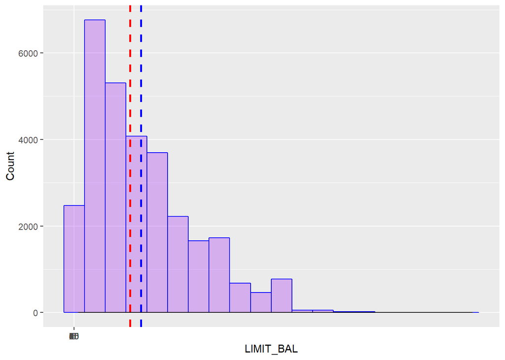

```r
create_histogram(credit_card_data, credit_card_data$LIMIT_BAL, "LIMIT_BAL", 20)
```

The distribution is slightly skewed to the right, indicating that higher limit was given to less people, which makes sense

#### AGE

```
## Distribution of AGE
```

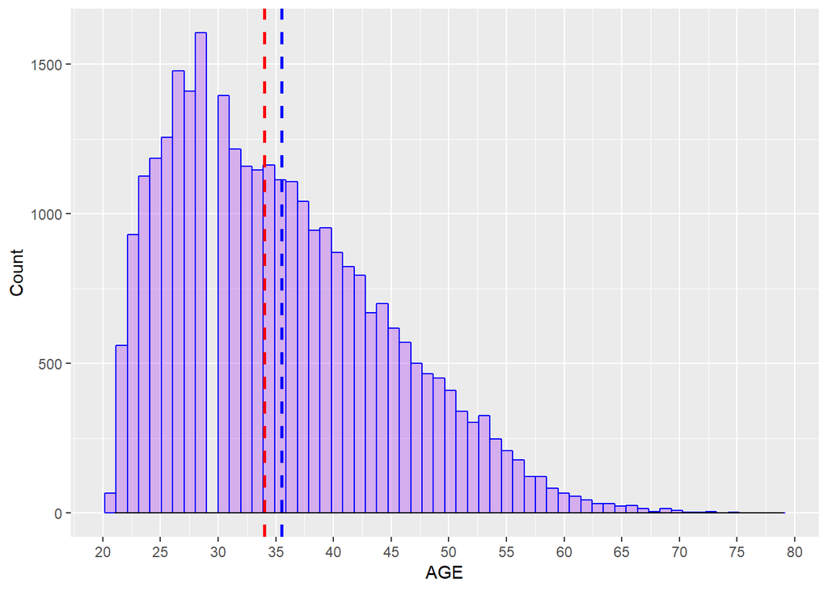

```r
create_histogram(credit_card_data, credit_card_data$AGE, "AGE", 60)
```

### Creating bar plots for factor variables SEX, MARRIAGE, EDUCATION and DEFAULT PAYMENT

#### SEX

```
## Distribution by SEX
```

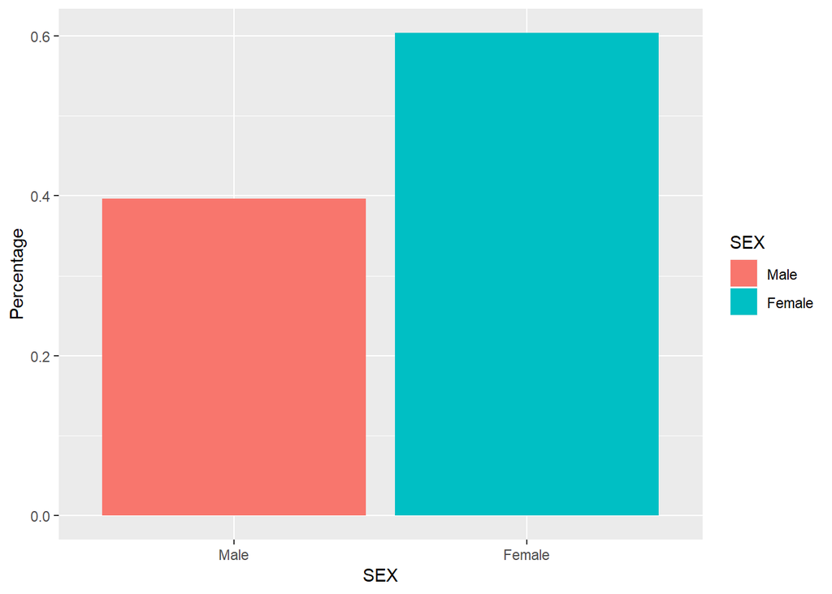

```r
create_bar_plot(credit_card_data, credit_card_data$SEX, "SEX")
```

60 % of the customers are females compared to 40% males

#### EDUCATION

```
## Distribution by EDUCATION
```

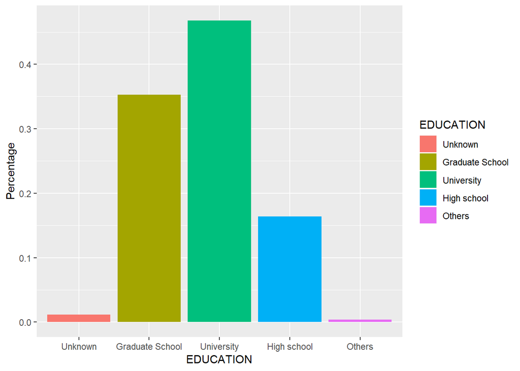

```r
create_bar_plot(credit_card_data, credit_card_data$EDUCATION, "EDUCATION")
```

We can see that about 47% customers have attended university, and about 35% have attended graduate school

#### MARRIAGE

```
## Distribution by MARRIAGE
```

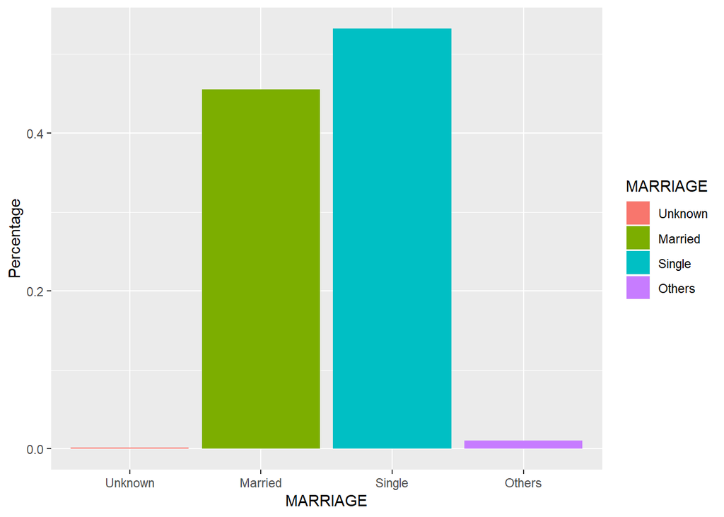

```r
create_bar_plot(credit_card_data, credit_card_data$MARRIAGE, "MARRIAGE")
```

There are more customers who are Single as opposed those who are Married

#### DEFAULT PAYMENT NEXT MONTH

```
## Distribution by DEFAULT PAYMENT NEXT MONTH
```

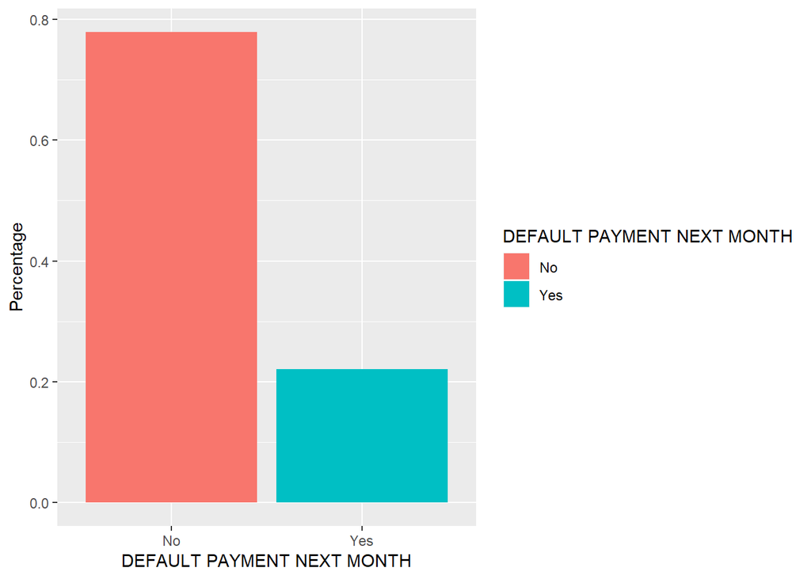

```r
create_bar_plot(credit_card_data, credit_card_data$default.payment.next.month, "DEFAULT PAYMENT NEXT MONTH")
```

About 21% of the customers defaulted

### Comparing DEFAULT PAYMENT NEXT MONTH with respect to SEX, MARRIAGE and EDUCATION

#### SEX Vs DEFAULT PAYMENT NEXT MONTH

```
## Distribution by SEX and DEFAULT PAYMENT NEXT MONTH
```

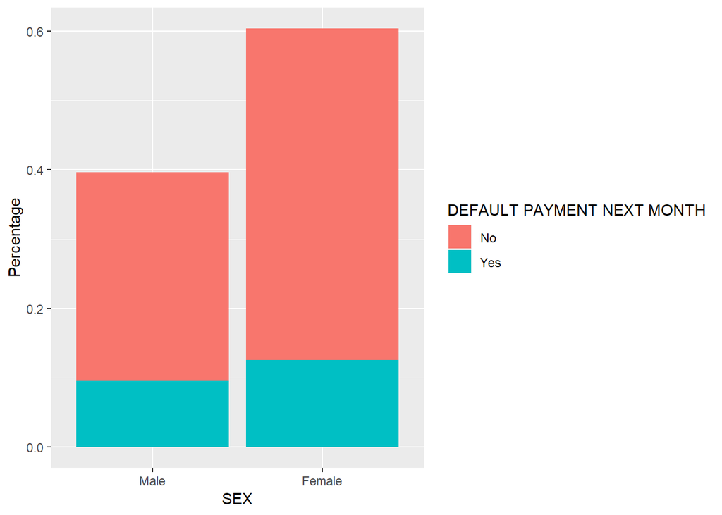

```r
create_stacked_bar_plot(credit_card_data, credit_card_data$SEX, "SEX", credit_card_data$default.payment.next.month, "DEFAULT PAYMENT NEXT MONTH")
```

We see that 25% of male customers defaulted, compared to 20% female customers

#### EDUCATION Vs DEFAULT PAYMENT NEXT MONTH

```
## Distribution by EDUCATION and DEFAULT PAYMENT NEXT MONTH
```

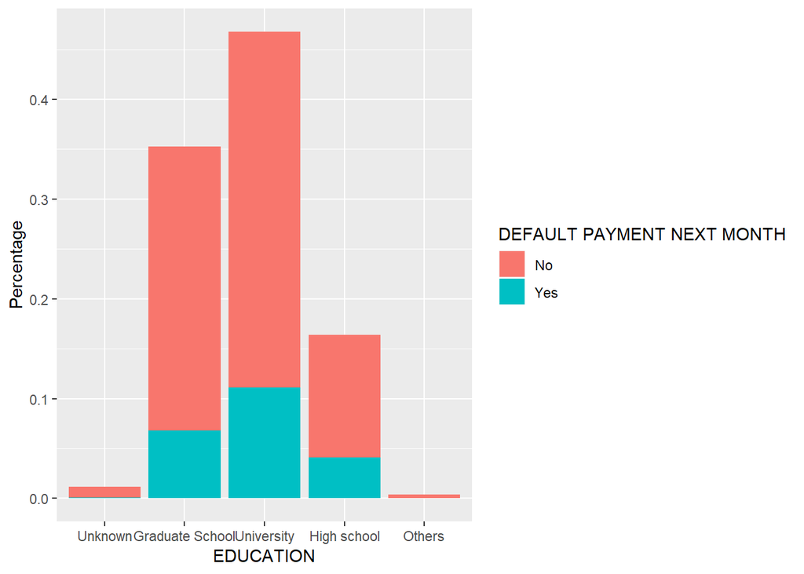

```r
create_stacked_bar_plot(credit_card_data, credit_card_data$EDUCATION, "EDUCATION", credit_card_data$default.payment.next.month, "DEFAULT PAYMENT NEXT MONTH")
```

We see that about 20 % of those who attended Graduate School Defaulted About 22% of University customers defaulted and about 25 % of customers who just attended high school defaulted

#### MARRIAGE Vs DEFAULT PAYMENT NEXT MONTH

```
## Distribution by MARRIAGE and DEFAULT PAYMENT NEXT MONTH
```

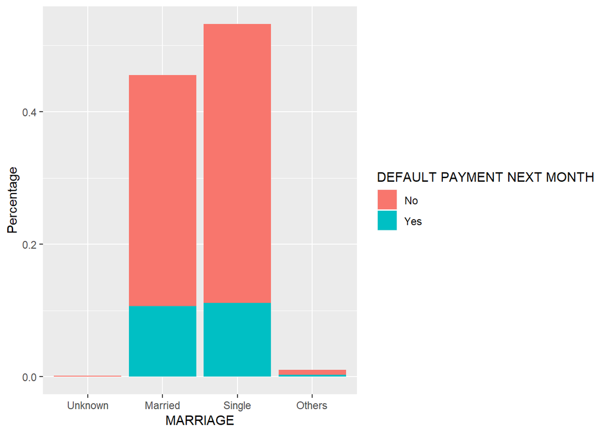

```r
create_stacked_bar_plot(credit_card_data, credit_card_data$MARRIAGE, "MARRIAGE", credit_card_data$default.payment.next.month, "DEFAULT PAYMENT NEXT MONTH")
```

About 24 % of married customers defaulted as opposed to 20 % single customers

### Creating Feature Density Plots

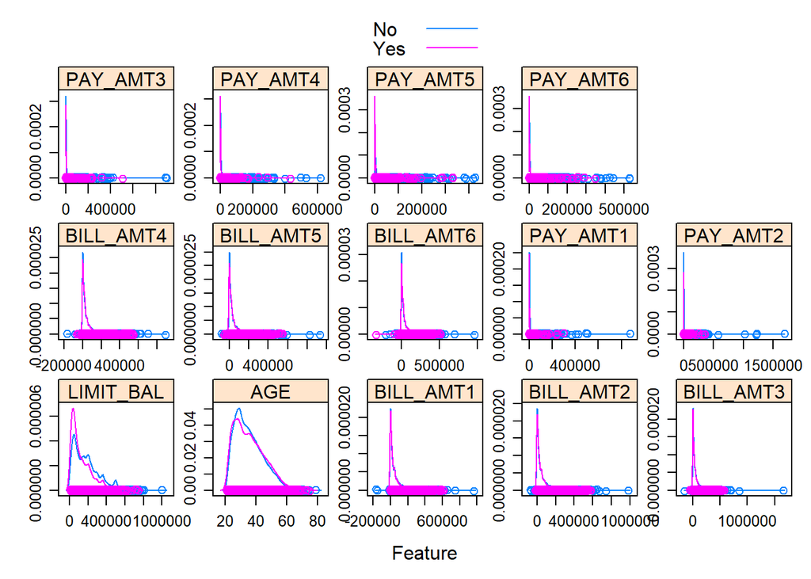

```r
plot_type <- "density"
create_feature_plot(numeric_var_data, credit_card_data$default.payment.next.month, plot_type)
```

#### LIMIT_BAL

We can see that the density plots of defaulters and non-defaulters is fairly different with respect to balance limit

#### AGE

We can see that the density plots of defaulters and non-defaulters is slightly different with respect to balance limit

#### BILL AMTs

Through visual inspection we can infer that balance amounts do not have differentiating power

#### PAY AMTs

Through visual inspection we can infer that payment amounts do not have differentiating power

### Outlier Detection

#### Creating box plots to do visual inspection about outliers

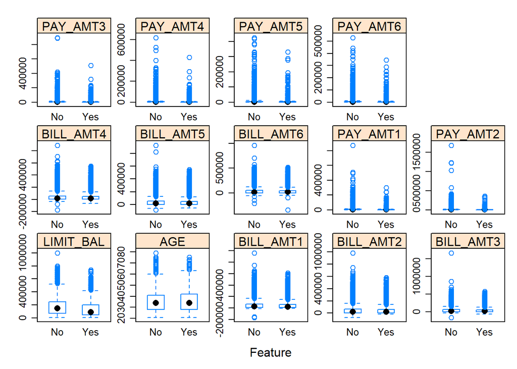

```r
plot_type <- "box"
create_feature_plot(numeric_var_data, credit_card_data$default.payment.next.month, plot_type)
```

### Feature Selection

#### Determining association between the target variable and the other categorical variables using Chi-squared Test for Independence

```r
lapply(factor_var_data, function(x) chi.squared(x~., factor_var_data))
```

```
## $SEX
##                            attr_importance
## SEX                             1.00000000
## EDUCATION                       0.02842841
## MARRIAGE                        0.03317131
## PAY_0                           0.06821297
## PAY_2                           0.07696795
## PAY_3                           0.07322469
## PAY_4                           0.06655410
## PAY_5                           0.05905950
## PAY_6                           0.04952495
## default.payment.next.month      0.03996058
##
## $EDUCATION
##                            attr_importance
## SEX                             0.02842841
## EDUCATION                       1.00000000
## MARRIAGE                        0.11451591
## PAY_0                           0.10134243
## PAY_2                           0.10913042
## PAY_3                           0.10541723
## PAY_4                           0.09729641
## PAY_5                           0.08884734
## PAY_6                           0.08593821
## default.payment.next.month      0.07316401
##
## $MARRIAGE
##                            attr_importance
## SEX                             0.03317131
## EDUCATION                       0.11451591
## MARRIAGE                        1.00000000
## PAY_0                           0.04009926
## PAY_2                           0.03793690
## PAY_3                           0.03649812
## PAY_4                           0.03963225
## PAY_5                           0.03726896
## PAY_6                           0.03460019
## default.payment.next.month      0.03447820
##
## $PAY_0
```

[output cut: 74 more lines]

```
## PAY_6                           1.00000000
## default.payment.next.month      0.25078778
##
## $default.payment.next.month
##                            attr_importance
## SEX                             0.03996058
## EDUCATION                       0.07316401
## MARRIAGE                        0.03447820
## PAY_0                           0.42292493
## PAY_2                           0.34031685
## PAY_3                           0.29566096
## PAY_4                           0.27937251
## PAY_5                           0.27065937
## PAY_6                           0.25078778
## default.payment.next.month      1.00000000
```

We can see that demographic details like SEX, EDUCATION and MARRIAGE are not very good variables for differentiating between defaulters and non-defaulters Previous payment statuses are well correlated with the target variable, with the most recent one being the most correlated Therefore, we will exclude these variables from modeling

```r
credit_card_data$SEX <- NULL
credit_card_data$EDUCATION <- NULL
credit_card_data$MARRIAGE <- NULL
```

Also we can see that PAY_0 is strongly correlated with PAY_2 and PAY_3 PAY_2 is strongly correlated with PAY_3 PAY_3 is strongly correlated with PAY_4 and PAY_5 PAY_4 is strongly correlated with PAY_5 and PAY_6 PAY_5 is strongly correlated with PAY_3 and PAY_4 and PAY_6 PAY_6 is strongly correlated with PAY_4 and PAY_5

Thus, in effect all payment statuses from PAY_0 to PAY_6 are strongly correlated with each other To avoid problems of multicollinearity, we will just retain the most recent status PAY_0

```r
credit_card_data$PAY_2 <- NULL
credit_card_data$PAY_3 <- NULL
credit_card_data$PAY_4 <- NULL
credit_card_data$PAY_5 <- NULL
credit_card_data$PAY_6 <- NULL
```

#### Determining correlation between numerical variables

```r
corr_matrix <- cor(numeric_var_data)
round(corr_matrix, 2)
```

```
##           LIMIT_BAL  AGE BILL_AMT1 BILL_AMT2 BILL_AMT3 BILL_AMT4 BILL_AMT5
## LIMIT_BAL      1.00 0.14      0.29      0.28      0.28      0.29      0.30
## AGE            0.14 1.00      0.06      0.05      0.05      0.05      0.05
## BILL_AMT1      0.29 0.06      1.00      0.95      0.89      0.86      0.83
## BILL_AMT2      0.28 0.05      0.95      1.00      0.93      0.89      0.86
## BILL_AMT3      0.28 0.05      0.89      0.93      1.00      0.92      0.88
## BILL_AMT4      0.29 0.05      0.86      0.89      0.92      1.00      0.94
## BILL_AMT5      0.30 0.05      0.83      0.86      0.88      0.94      1.00
## BILL_AMT6      0.29 0.05      0.80      0.83      0.85      0.90      0.95
## PAY_AMT1       0.20 0.03      0.14      0.28      0.24      0.23      0.22
## PAY_AMT2       0.18 0.02      0.10      0.10      0.32      0.21      0.18
## PAY_AMT3       0.21 0.03      0.16      0.15      0.13      0.30      0.25
## PAY_AMT4       0.20 0.02      0.16      0.15      0.14      0.13      0.29
## PAY_AMT5       0.22 0.02      0.17      0.16      0.18      0.16      0.14
## PAY_AMT6       0.22 0.02      0.18      0.17      0.18      0.18      0.16
##           BILL_AMT6 PAY_AMT1 PAY_AMT2 PAY_AMT3 PAY_AMT4 PAY_AMT5 PAY_AMT6
## LIMIT_BAL      0.29     0.20     0.18     0.21     0.20     0.22     0.22
## AGE            0.05     0.03     0.02     0.03     0.02     0.02     0.02
## BILL_AMT1      0.80     0.14     0.10     0.16     0.16     0.17     0.18
## BILL_AMT2      0.83     0.28     0.10     0.15     0.15     0.16     0.17
## BILL_AMT3      0.85     0.24     0.32     0.13     0.14     0.18     0.18
## BILL_AMT4      0.90     0.23     0.21     0.30     0.13     0.16     0.18
## BILL_AMT5      0.95     0.22     0.18     0.25     0.29     0.14     0.16
## BILL_AMT6      1.00     0.20     0.17     0.23     0.25     0.31     0.12
## PAY_AMT1       0.20     1.00     0.29     0.25     0.20     0.15     0.19
## PAY_AMT2       0.17     0.29     1.00     0.24     0.18     0.18     0.16
## PAY_AMT3       0.23     0.25     0.24     1.00     0.22     0.16     0.16
## PAY_AMT4       0.25     0.20     0.18     0.22     1.00     0.15     0.16
## PAY_AMT5       0.31     0.15     0.18     0.16     0.15     1.00     0.15
## PAY_AMT6       0.12     0.19     0.16     0.16     0.16     0.15     1.00
```

We can see that all Billed Amounts variables i.e. BILL_AMT1 through BILL_AMT6 are highly correlated to each other Therefore, to avoid multi-collinearity problem, we will only retain BILL_AMT1 and get rid of the other BilledAmount variables

```r
credit_card_data$BILL_AMT2 <- NULL
credit_card_data$BILL_AMT3 <- NULL
credit_card_data$BILL_AMT4 <- NULL
credit_card_data$BILL_AMT5 <- NULL
credit_card_data$BILL_AMT6 <- NULL
```

#### Automatic Feature Selection using Mean Decrease in Gini

```r
resampled_balanced_credit_data <- SMOTE(default.payment.next.month ~ ., credit_card_data, perc.over = 100, perc.under = 200)
fs_model <- randomForest(default.payment.next.month~., data=resampled_balanced_credit_data, importance=TRUE)

imp <- as.data.frame(randomForest::importance(fs_model))
imp <- data.frame(MeanDecreaseGini = imp$MeanDecreaseGini,
                  names   = rownames(imp))
imp[order(imp$MeanDecreaseGini,decreasing = T),]
```

```
##    MeanDecreaseGini     names
## 3          2331.833     PAY_0
## 4          1588.558 BILL_AMT1
## 5          1294.360  PAY_AMT1
## 6          1282.906  PAY_AMT2
## 1          1211.951 LIMIT_BAL
## 2          1132.941       AGE
## 7          1091.517  PAY_AMT3
## 10         1053.064  PAY_AMT6
## 8          1036.144  PAY_AMT4
## 9          1010.138  PAY_AMT5
```

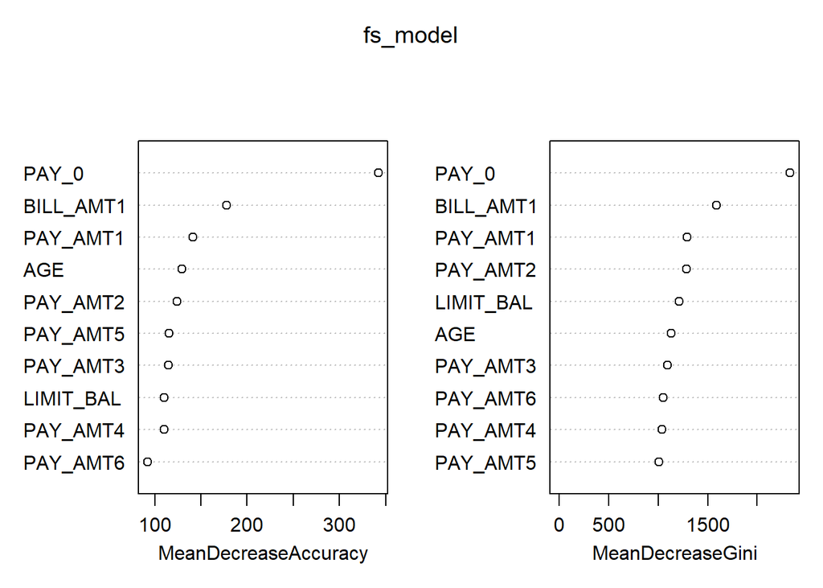

```r
randomForest::varImpPlot(fs_model)
```

The variable whose removal from the model leads most decrease in the GINI value is the most differentiating and thus the most important variable

We choose PAY_0 - Repayment status in the last payment cycle BILL_AMT1 - Amount of bill statement in the last payment cycle (NT dollar) AGE - Age of the debtor PAY_AMT1 - Amount paid in the last payment cycle PAY_AMT2 - Amount paid in the 2nd last payment cycle LIMIT_BAL - Amount of given credit in NT dollars PAY_AMT3 - Amount paid in the 3rd last payment cycle PAY_AMT6 - Amount paid in the 6th last payment cycle PAY_AMT5 - Amount paid in the 5th last payment cycle PAY_AMT4 - Amount paid in the 4th last payment cycle

The variables selected by the algorithm also make business sense, as payment behavior in recent past along with the credit limit and age of the debtor should give a good idea about likelihood of default

```r
features_to_select <- c("PAY_0", "BILL_AMT1", "AGE", "PAY_AMT1", "PAY_AMT2", "PAY_AMT3", "PAY_AMT4", "PAY_AMT5", "PAY_AMT6", "LIMIT_BAL","default.payment.next.month")
```

## Data Partitioning: Creating training, validation and test data sets

```r
set.seed(430)
trn_idx <- createDataPartition(credit_card_data$default.payment.next.month, p = 0.8, list = FALSE)
X_train <- credit_card_data[trn_idx, which(names(credit_card_data) %in% features_to_select)]
X_valid_test <- credit_card_data[-trn_idx, which(names(credit_card_data) %in% features_to_select)]

valid_idx <- createDataPartition(X_valid_test$default.payment.next.month, p = 0.5, list = FALSE)
X_valid <- X_valid_test[valid_idx, ]
X_test <- X_valid_test[-valid_idx, ]
```

Since the data set is unbalanced, with Yes: No being 1:4 This can be an issue as the ‘No’ class will dominate the outcome of classification Therefore we will create a new data set using SMOTE such that we get a balanced data set by oversampling ‘Yes’ observations and undersampling ‘No’ observations

```r
prop.table(table(X_train$default.payment.next.month))
```

```
##
##        No       Yes
## 0.7788009 0.2211991
```

```r
X_train <- SMOTE(default.payment.next.month ~ ., X_train, perc.over = 100, perc.under = 200)

prop.table(table(X_train$default.payment.next.month))
```

```
##
##  No Yes
## 0.5 0.5
```

## Modeling

### Defining a 10-folds cross-validation scheme

```r
folds <- 10
cvIndex <- createFolds(factor(X_train$default.payment.next.month), folds, returnTrain = T)
control <- trainControl(index = cvIndex, method = "cv", number = folds, search = "random", allowParallel = T, classProbs = T, summaryFunction = f1)
```

### Metric for Optimization

Since our objective is to maximize the detection of Defaulters, we want our classifiers to be sensitive to the positive class, at the same time trying to minimize the cases of false positives i.e. labeling someone as Defaulter when they are not Therefore, we will use F1-score as the metric, which is mathematically the harmonic mean of precision and recall

```r
metric <- "F1"
```

### Logistic Regression

#### Training the Model

```r
method <- "glm"

model <- train(
  form = default.payment.next.month ~ .,
  data = X_train,
  trControl = control,
  method = method,
  metric = metric
)

summary(model)
```

```
##
## Call:
## NULL
##
## Deviance Residuals:
##      Min        1Q    Median        3Q       Max
## -2.38809  -0.96383   0.00125   1.02779   3.12883
##
## Coefficients:
##                  Estimate    Std. Error z value             Pr(>|z|)
## (Intercept) -0.0698289159  0.0855639025  -0.816             0.414442
## LIMIT_BAL   -0.0000026139  0.0000001543 -16.941 < 0.0000000000000002 ***
## AGE          0.0081203804  0.0016715887   4.858      0.0000011864823 ***
## `PAY_0-1`    0.0209959680  0.0636288615   0.330             0.741418
## PAY_00      -0.5600800185  0.0640754355  -8.741 < 0.0000000000000002 ***
## PAY_01       0.7675515902  0.0667431156  11.500 < 0.0000000000000002 ***
## PAY_02       2.0185325272  0.0793068180  25.452 < 0.0000000000000002 ***
## PAY_03       2.4691446355  0.1835752495  13.450 < 0.0000000000000002 ***
## PAY_04       1.9192744361  0.2937613916   6.533      0.0000000000643 ***
## PAY_05       0.8424057791  0.4021946866   2.095             0.036213 *
## PAY_06       1.4477763933  0.7963046427   1.818             0.069046 .
## PAY_07      12.3289373767 93.4731080598   0.132             0.895065
## PAY_08       1.5285387796  0.5490350771   2.784             0.005369 **
## BILL_AMT1    0.0000026059  0.0000002781   9.369 < 0.0000000000000002 ***
## PAY_AMT1    -0.0000095817  0.0000019090  -5.019      0.0000005190273 ***
## PAY_AMT2    -0.0000086473  0.0000016394  -5.275      0.0000001329148 ***
## PAY_AMT3    -0.0000035834  0.0000013280  -2.698             0.006967 **
## PAY_AMT4    -0.0000053400  0.0000015011  -3.557             0.000375 ***
## PAY_AMT5    -0.0000056494  0.0000014999  -3.766             0.000166 ***
## PAY_AMT6    -0.0000033501  0.0000012763  -2.625             0.008667 **
## ---
## Signif. codes:  0 '***' 0.001 '**' 0.01 '*' 0.05 '.' 0.1 ' ' 1
##
## (Dispersion parameter for binomial family taken to be 1)
##
##     Null deviance: 29439  on 21235  degrees of freedom
## Residual deviance: 24613  on 21216  degrees of freedom
## AIC: 24653
##
## Number of Fisher Scoring iterations: 11
```

#### Model Evaluation

#### Training

```r
data <- X_train
```

#### Kolmogorov-Smirnov (KS) Statistic

We will calculate KS statistic on the training data to get the best threshold at which we get the maximum separation between the two classes of the target variable

```r
ks_statistic <- KS(predict(model, newdata=data), data$default.payment.next.month)
threshold <- ks_statistic
```

##### Confusion Matrix

```r
evaluate_confusion_matrix(data, model, threshold)
```

```
## Confusion Matrix and Statistics
##
##           Reference
## Prediction   No  Yes
##        No  6557 2883
##        Yes 4061 7735
##
##                Accuracy : 0.673
##                  95% CI : (0.6667, 0.6793)
##     No Information Rate : 0.5
##     P-Value [Acc > NIR] : < 0.00000000000000022
##
##                   Kappa : 0.346
##  Mcnemar's Test P-Value : < 0.00000000000000022
##
##               Precision : 0.6557
##                  Recall : 0.7285
##                      F1 : 0.6902
##              Prevalence : 0.5000
##          Detection Rate : 0.3642
##    Detection Prevalence : 0.5555
##       Balanced Accuracy : 0.6730
##
##        'Positive' Class : Yes
##
```

##### ROC-AUC

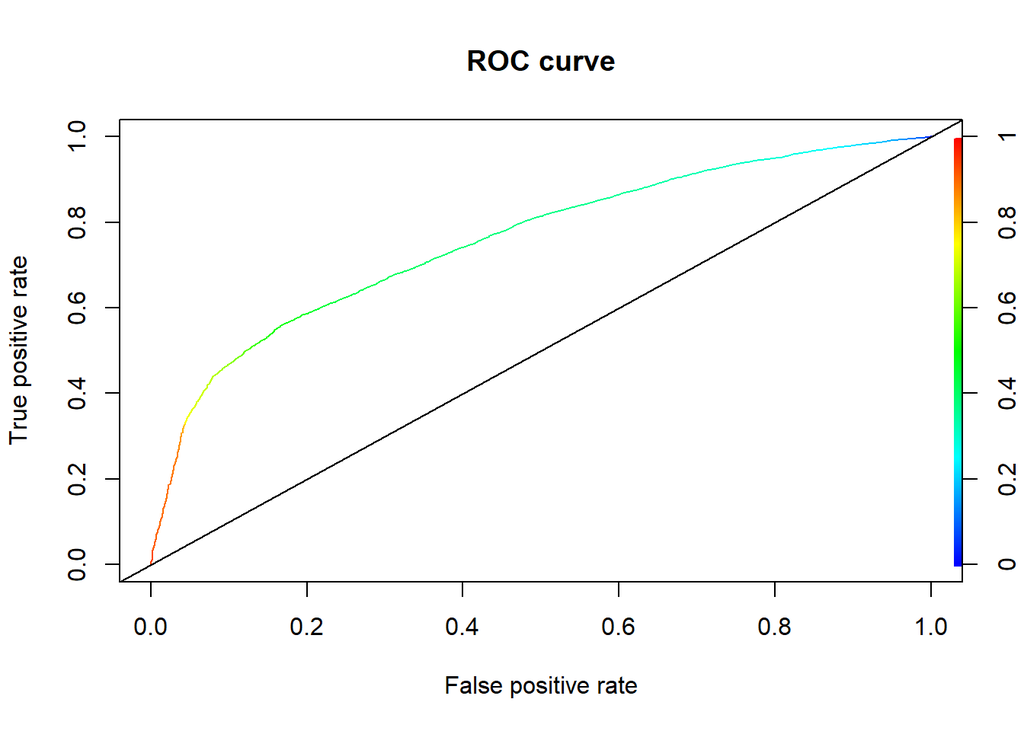

```
## AUC:  0.7569429
```

```r
evaluate_roc_auc(data, model)
```

#### Validation

```r
data <- X_valid
```

#### Kolmogorov-Smirnov (KS) Statistic

```r
KS(predict(model, newdata=data), data$default.payment.next.month)
```

```
## [1] 0.3554165
```

##### Confusion Matrix

```r
evaluate_confusion_matrix(data, model, threshold)
```

```
## Confusion Matrix and Statistics
##
##           Reference
## Prediction   No  Yes
##        No  1417  197
##        Yes  919  467
##
##                Accuracy : 0.628
##                  95% CI : (0.6104, 0.6453)
##     No Information Rate : 0.7787
##     P-Value [Acc > NIR] : 1
##
##                   Kappa : 0.2231
##  Mcnemar's Test P-Value : <0.0000000000000002
##
##               Precision : 0.3369
##                  Recall : 0.7033
##                      F1 : 0.4556
##              Prevalence : 0.2213
##          Detection Rate : 0.1557
##    Detection Prevalence : 0.4620
##       Balanced Accuracy : 0.6550
##
##        'Positive' Class : Yes
##
```

##### ROC-AUC

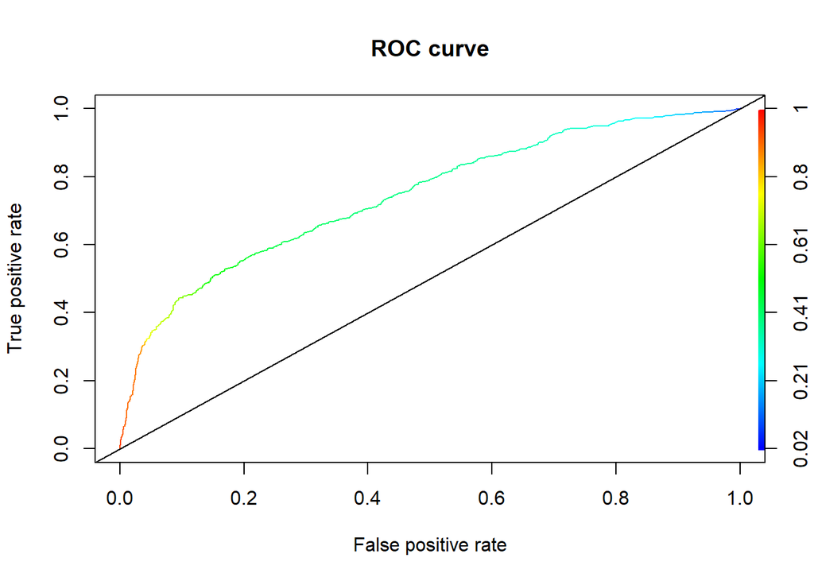

```
## AUC:  0.7434479
```

```r
evaluate_roc_auc(data, model)
```

#### Test

```r
data <- X_test
```

#### Kolmogorov-Smirnov (KS) Statistic

```r
KS(predict(model, newdata=data), data$default.payment.next.month)
```

```
## [1] 0.3803152
```

##### Confusion Matrix

```r
evaluate_confusion_matrix(data, model, threshold)
```

```
## Confusion Matrix and Statistics
##
##           Reference
## Prediction   No  Yes
##        No  1452  192
##        Yes  884  471
##
##                Accuracy : 0.6412
##                  95% CI : (0.6237, 0.6584)
##     No Information Rate : 0.7789
##     P-Value [Acc > NIR] : 1
##
##                   Kappa : 0.2417
##  Mcnemar's Test P-Value : <0.0000000000000002
##
##               Precision : 0.3476
##                  Recall : 0.7104
##                      F1 : 0.4668
##              Prevalence : 0.2211
##          Detection Rate : 0.1571
##    Detection Prevalence : 0.4518
##       Balanced Accuracy : 0.6660
##
##        'Positive' Class : Yes
##
```

##### ROC-AUC

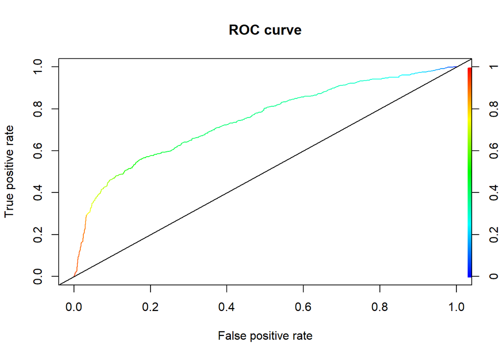

```
## AUC:  0.7465289
```

```r
evaluate_roc_auc(data, model)
```

### XGBoost Classifier

#### Training the Model

```r
method <- "xgbTree"

model <- train(
  form = default.payment.next.month ~ .,
  data = X_train,
  trControl = control,
  method = method,
  metric = metric
)

summary(model)
```

```
##               Length Class              Mode
## handle             1 xgb.Booster.handle externalptr
## raw           234493 -none-             raw
## niter              1 -none-             numeric
## call               5 -none-             call
## params             8 -none-             list
## callbacks          1 -none-             list
## feature_names     19 -none-             character
## nfeatures          1 -none-             numeric
## xNames            19 -none-             character
## problemType        1 -none-             character
## tuneValue          7 data.frame         list
## obsLevels          2 -none-             character
## param              0 -none-             list
```

#### Best parameters for the model

```r
model$bestTune
```

```
##   nrounds max_depth       eta    gamma colsample_bytree min_child_weight
## 3     124         6 0.5488872 3.958553        0.4489763               14
##   subsample
## 3  0.580871
```

#### Training the model with the best parameters

```r
final_grid <- expand.grid(
                nrounds = model$bestTune[, 'nrounds'],
                eta = model$bestTune[, 'eta'],
                max_depth = model$bestTune[, 'max_depth'],
                gamma = model$bestTune[, 'gamma'],
                colsample_bytree = model$bestTune[, 'colsample_bytree'],
                min_child_weight = model$bestTune[, 'min_child_weight'],
                subsample = model$bestTune[, 'subsample']
              )

model <- train(
                form = default.payment.next.month ~ .,
                data = X_train,
                trControl = control,
                method = method,
                tuneGrid = final_grid,
                metric = metric
              )
```

#### Model Evaluation

#### Training

```r
data <- X_train
```

#### Kolmogorov-Smirnov (KS) Statistic

```r
ks_statistic <- KS(predict(model, newdata=data), data$default.payment.next.month)
```

##### Confusion Matrix

```r
evaluate_confusion_matrix(data, model)
```

```
## Confusion Matrix and Statistics
##
##           Reference
## Prediction   No  Yes
##        No  9160 1905
##        Yes 1458 8713
##
##                Accuracy : 0.8416
##                  95% CI : (0.8367, 0.8465)
##     No Information Rate : 0.5
##     P-Value [Acc > NIR] : < 0.00000000000000022
##
##                   Kappa : 0.6833
##  Mcnemar's Test P-Value : 0.00000000000001462
##
##               Precision : 0.8567
##                  Recall : 0.8206
##                      F1 : 0.8382
##              Prevalence : 0.5000
##          Detection Rate : 0.4103
##    Detection Prevalence : 0.4790
##       Balanced Accuracy : 0.8416
##
##        'Positive' Class : Yes
##
```

##### ROC-AUC

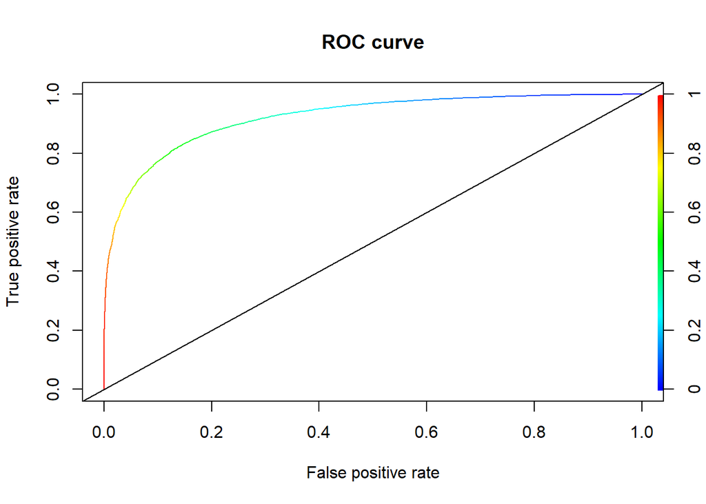

```
## AUC:  0.9210594
```

```r
evaluate_roc_auc(data, model)
```

#### Validation

```r
data <- X_valid
```

#### Kolmogorov-Smirnov (KS) Statistic

```r
KS(predict(model, newdata=data), data$default.payment.next.month)
```

```
## [1] 0.2745864
```

##### Confusion Matrix

```r
evaluate_confusion_matrix(data, model, threshold)
```

```
## Confusion Matrix and Statistics
##
##           Reference
## Prediction   No  Yes
##        No  1508  235
##        Yes  828  429
##
##                Accuracy : 0.6457
##                  95% CI : (0.6282, 0.6628)
##     No Information Rate : 0.7787
##     P-Value [Acc > NIR] : 1
##
##                   Kappa : 0.221
##  Mcnemar's Test P-Value : <0.0000000000000002
##
##               Precision : 0.3413
##                  Recall : 0.6461
##                      F1 : 0.4466
##              Prevalence : 0.2213
##          Detection Rate : 0.1430
##    Detection Prevalence : 0.4190
##       Balanced Accuracy : 0.6458
##
##        'Positive' Class : Yes
##
```

##### ROC-AUC

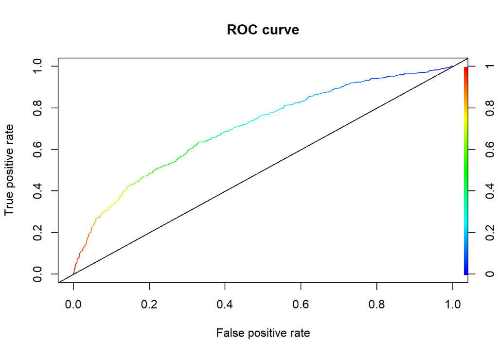

```
## AUC:  0.7044144
```

```r
evaluate_roc_auc(data, model)
```

#### Test

```r
data <- X_test
```

#### Kolmogorov-Smirnov (KS) Statistic

```r
KS(predict(model, newdata=data), data$default.payment.next.month)
```

```
## [1] 0.3249647
```

##### Confusion Matrix

```r
evaluate_confusion_matrix(data, model, threshold)
```

```
## Confusion Matrix and Statistics
##
##           Reference
## Prediction   No  Yes
##        No  1502  220
##        Yes  834  443
##
##                Accuracy : 0.6485
##                  95% CI : (0.6312, 0.6657)
##     No Information Rate : 0.7789
##     P-Value [Acc > NIR] : 1
##
##                   Kappa : 0.2337
##  Mcnemar's Test P-Value : <0.0000000000000002
##
##               Precision : 0.3469
##                  Recall : 0.6682
##                      F1 : 0.4567
##              Prevalence : 0.2211
##          Detection Rate : 0.1477
##    Detection Prevalence : 0.4258
##       Balanced Accuracy : 0.6556
##
##        'Positive' Class : Yes
##
```

##### ROC-AUC

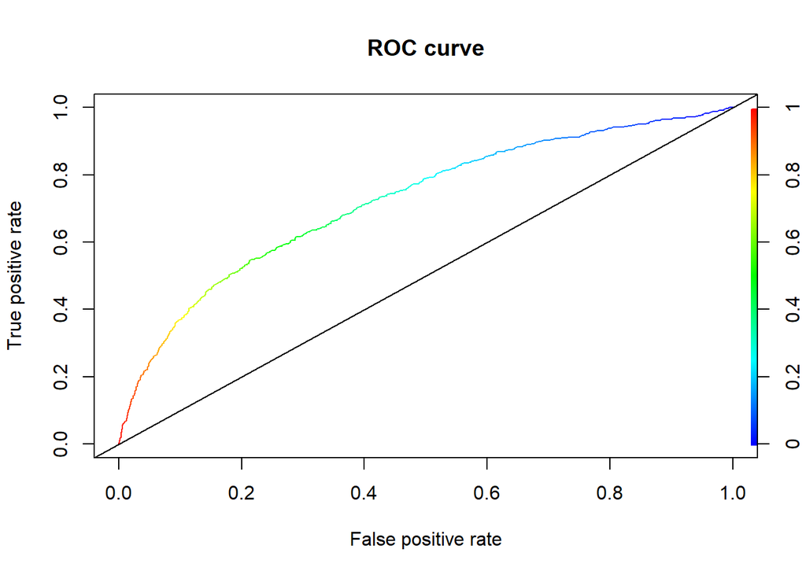

```
## AUC:  0.7221992
```

```r
evaluate_roc_auc(data, model)
```

### Naive-Bayes Classifier

#### Training the Model

```r
method <- "naive_bayes"

model <- train(
  form = default.payment.next.month ~ .,
  data = X_train,
  trControl = control,
  method = method,
  metric = metric
)

summary(model)
```

```
##             Length Class      Mode
## data         2     -none-     list
## levels       2     -none-     character
## laplace      1     -none-     numeric
## tables      19     -none-     list
## prior        2     table      numeric
## usekernel    1     -none-     logical
## call         6     -none-     call
## xNames      19     -none-     character
## problemType  1     -none-     character
## tuneValue    3     data.frame list
## obsLevels    2     -none-     character
## param        0     -none-     list
```

#### Best parameters for the model

```r
model$bestTune
```

```
##   laplace usekernel adjust
## 2       0      TRUE      1
```

#### Training the model with the best parameters

```r
final_grid <- expand.grid(
  laplace = model$bestTune[, 'laplace'],
  usekernel = model$bestTune[, 'usekernel'],
  adjust = model$bestTune[, 'adjust']
)

model <- train(
                form = default.payment.next.month ~ .,
                data = X_train,
                trControl = control,
                method = method,
                tuneGrid = final_grid,
                metric = metric
              )
```

#### Model Evaluation

#### Training

```r
data <- X_train
```

#### Kolmogorov-Smirnov (KS) Statistic

```r
KS(predict(model, newdata=data), data$default.payment.next.month)
```

```
## [1] 0.292993
```

##### Confusion Matrix

```r
evaluate_confusion_matrix(data, model)
```

```
## Confusion Matrix and Statistics
##
##           Reference
## Prediction   No  Yes
##        No  8906 5795
##        Yes 1712 4823
##
##                Accuracy : 0.6465
##                  95% CI : (0.64, 0.6529)
##     No Information Rate : 0.5
##     P-Value [Acc > NIR] : < 0.00000000000000022
##
##                   Kappa : 0.293
##  Mcnemar's Test P-Value : < 0.00000000000000022
##
##               Precision : 0.7380
##                  Recall : 0.4542
##                      F1 : 0.5624
##              Prevalence : 0.5000
##          Detection Rate : 0.2271
##    Detection Prevalence : 0.3077
##       Balanced Accuracy : 0.6465
##
##        'Positive' Class : Yes
##
```

##### ROC-AUC

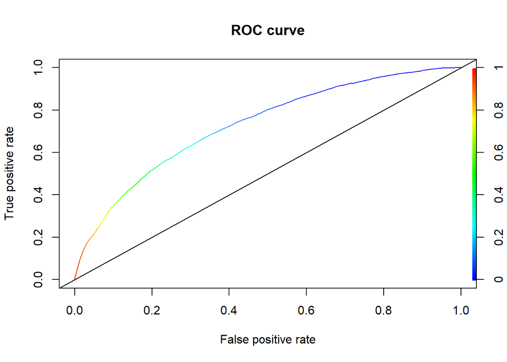

```
## AUC:  0.7302477
```

```r
evaluate_roc_auc(data, model)
```

#### Validation

```r
data <- X_valid
```

#### Kolmogorov-Smirnov (KS) Statistic

```r
KS(predict(model, newdata=data), data$default.payment.next.month)
```

```
## [1] 0.2555444
```

##### Confusion Matrix

```r
evaluate_confusion_matrix(data, model)
```

```
## Confusion Matrix and Statistics
##
##           Reference
## Prediction   No  Yes
##        No  1969  390
##        Yes  367  274
##
##                Accuracy : 0.7477
##                  95% CI : (0.7317, 0.7631)
##     No Information Rate : 0.7787
##     P-Value [Acc > NIR] : 1.0000
##
##                   Kappa : 0.2588
##  Mcnemar's Test P-Value : 0.4239
##
##               Precision : 0.42746
##                  Recall : 0.41265
##                      F1 : 0.41992
##              Prevalence : 0.22133
##          Detection Rate : 0.09133
##    Detection Prevalence : 0.21367
##       Balanced Accuracy : 0.62777
##
##        'Positive' Class : Yes
##
```

##### ROC-AUC

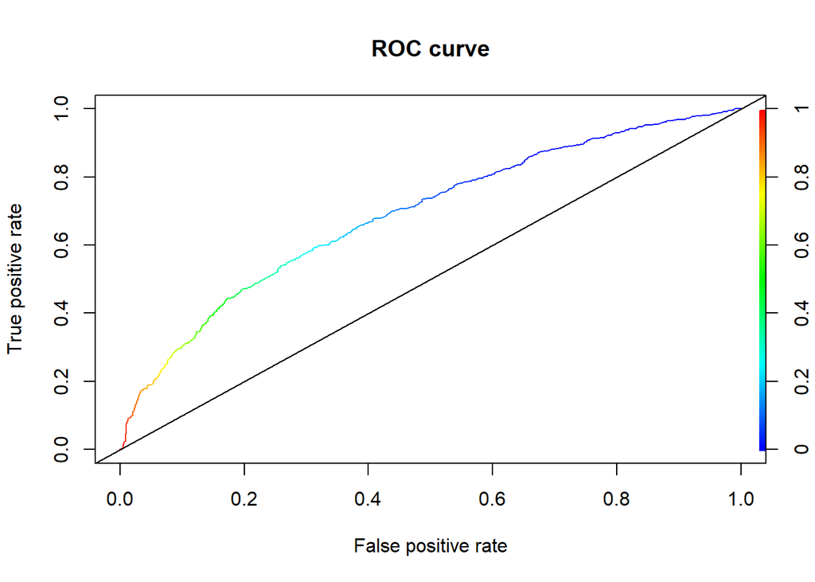

```
## AUC:  0.6886424
```

```r
evaluate_roc_auc(data, model)
```

#### Test

```r
data <- X_test
```

#### Kolmogorov-Smirnov (KS) Statistic

```r
KS(predict(model, newdata=data), data$default.payment.next.month)
```

```
## [1] 0.2564309
```

##### Confusion Matrix

```r
evaluate_confusion_matrix(data, model)
```

```
## Confusion Matrix and Statistics
##
##           Reference
## Prediction   No  Yes
##        No  1952  384
##        Yes  384  279
##
##                Accuracy : 0.7439
##                  95% CI : (0.7279, 0.7595)
##     No Information Rate : 0.7789
##     P-Value [Acc > NIR] : 1
##
##                   Kappa : 0.2564
##  Mcnemar's Test P-Value : 1
##
##               Precision : 0.42081
##                  Recall : 0.42081
##                      F1 : 0.42081
##              Prevalence : 0.22107
##          Detection Rate : 0.09303
##    Detection Prevalence : 0.22107
##       Balanced Accuracy : 0.62822
##
##        'Positive' Class : Yes
##
```

##### ROC-AUC

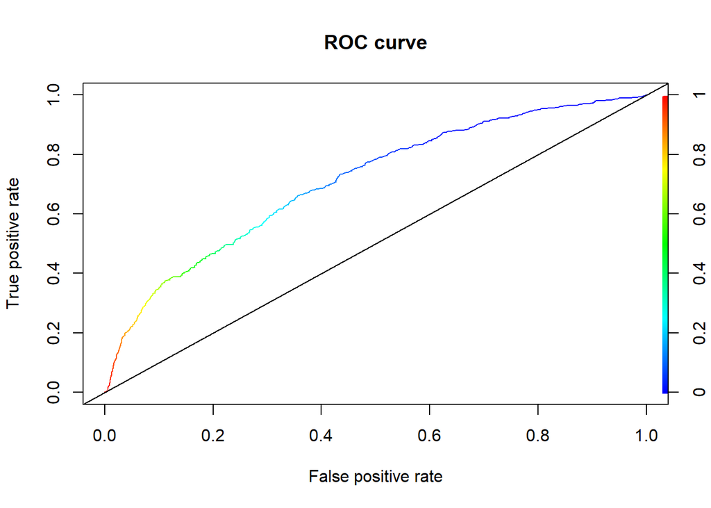

```
## AUC:  0.70981
```

```r
evaluate_roc_auc(data, model)
```

### Random Forest Classifier

#### Training the Model

```r
method <- "RRF"

model <- train(
  form = default.payment.next.month ~ .,
  data = X_train,
  trControl = control,
  method = method,
  metric = metric
)

summary(model)
```

```
##                 Length Class      Mode
## call                5  -none-     call
## type                1  -none-     character
## predicted       21236  factor     numeric
## err.rate         1500  -none-     numeric
## confusion           6  -none-     numeric
## votes           42472  matrix     numeric
## oob.times       21236  -none-     numeric
## classes             2  -none-     character
## importance         19  -none-     numeric
## importanceSD        0  -none-     NULL
## localImportance     0  -none-     NULL
## proximity           0  -none-     NULL
## ntree               1  -none-     numeric
## mtry                1  -none-     numeric
## forest             14  -none-     list
## y               21236  factor     numeric
## test                0  -none-     NULL
## inbag               0  -none-     NULL
## feaSet             10  -none-     numeric
## coefReg            19  -none-     numeric
## xNames             19  -none-     character
## problemType         1  -none-     character
## tuneValue           3  data.frame list
## obsLevels           2  -none-     character
## param               0  -none-     list
```

#### Best parameters for the model

```r
model$bestTune
```

```
##   mtry   coefReg   coefImp
## 2    9 0.1862059 0.8079228
```

#### Training the model with the best parameters

```r
final_grid <- expand.grid(
  mtry = model$bestTune[, 'mtry'],
  coefReg = model$bestTune[, 'coefReg'],
  coefImp = model$bestTune[, 'coefImp']
)

model <- train(
                form = default.payment.next.month ~ .,
                data = X_train,
                trControl = control,
                method = method,
                tuneGrid = final_grid,
                metric = metric
              )
```

#### Model Evaluation

#### Training

```r
data <- X_train
```

#### Kolmogorov-Smirnov (KS) Statistic

```r
KS(predict(model, newdata=data), data$default.payment.next.month)
```

```
## [1] 0.997363
```

##### Confusion Matrix

```r
evaluate_confusion_matrix(data, model, threshold)
```

```
## Confusion Matrix and Statistics
##
##           Reference
## Prediction    No   Yes
##        No  10598     9
##        Yes    20 10609
##
##                Accuracy : 0.9986
##                  95% CI : (0.998, 0.9991)
##     No Information Rate : 0.5
##     P-Value [Acc > NIR] : < 0.0000000000000002
##
##                   Kappa : 0.9973
##  Mcnemar's Test P-Value : 0.06332
##
##               Precision : 0.9981
##                  Recall : 0.9992
##                      F1 : 0.9986
##              Prevalence : 0.5000
##          Detection Rate : 0.4996
##    Detection Prevalence : 0.5005
##       Balanced Accuracy : 0.9986
##
##        'Positive' Class : Yes
##
```

##### ROC-AUC

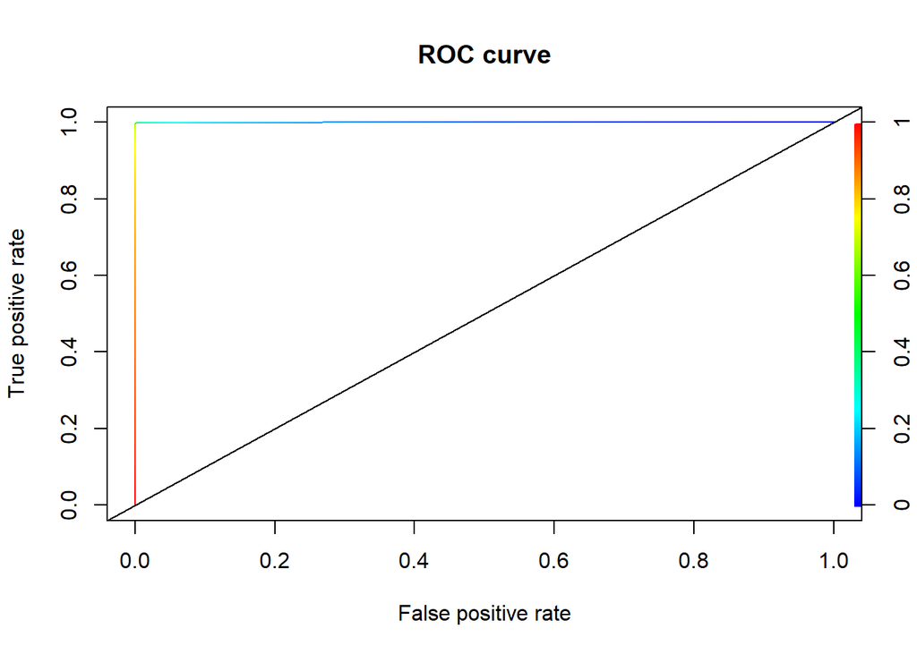

```
## AUC:  0.9999086
```

```r
evaluate_roc_auc(data, model)
```

#### Validation

```r
data <- X_valid
```

#### Kolmogorov-Smirnov (KS) Statistic

```r
KS(predict(model, newdata=data), data$default.payment.next.month)
```

```
## [1] 0.2515782
```

##### Confusion Matrix

```r
evaluate_confusion_matrix(data, model)
```

```
## Confusion Matrix and Statistics
##
##           Reference
## Prediction   No  Yes
##        No  1624  295
##        Yes  712  369
##
##                Accuracy : 0.6643
##                  95% CI : (0.6471, 0.6812)
##     No Information Rate : 0.7787
##     P-Value [Acc > NIR] : 1
##
##                   Kappa : 0.2049
##  Mcnemar's Test P-Value : <0.0000000000000002
##
##               Precision : 0.3414
##                  Recall : 0.5557
##                      F1 : 0.4229
##              Prevalence : 0.2213
##          Detection Rate : 0.1230
##    Detection Prevalence : 0.3603
##       Balanced Accuracy : 0.6255
##
##        'Positive' Class : Yes
##
```

##### ROC-AUC

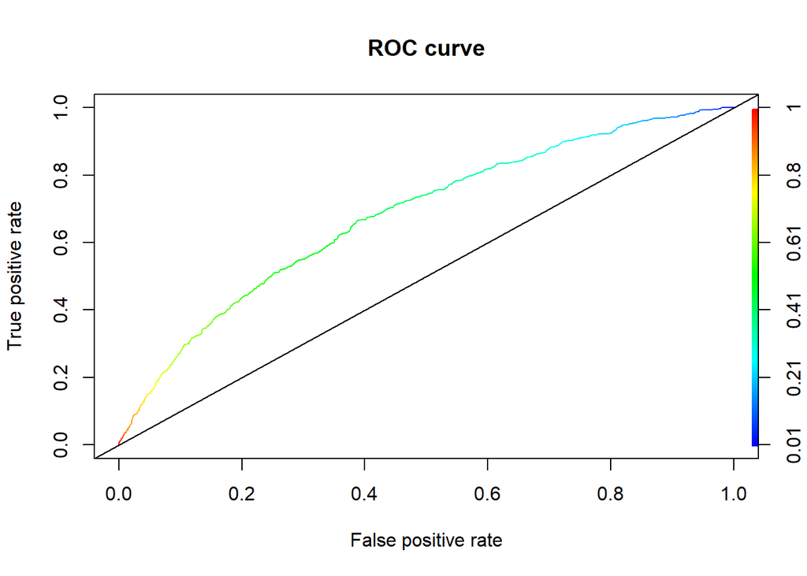

```
## AUC:  0.6810775
```

```r
evaluate_roc_auc(data, model)
```

#### Test

```r
data <- X_test
```

#### Kolmogorov-Smirnov (KS) Statistic

```r
KS(predict(model, newdata=data), data$default.payment.next.month)
```

```
## [1] 0.2449173
```

##### Confusion Matrix

```r
evaluate_confusion_matrix(data, model)
```

```
## Confusion Matrix and Statistics
##
##           Reference
## Prediction   No  Yes
##        No  1612  295
##        Yes  724  368
##
##                Accuracy : 0.6602
##                  95% CI : (0.643, 0.6772)
##     No Information Rate : 0.7789
##     P-Value [Acc > NIR] : 1
##
##                   Kappa : 0.199
##  Mcnemar's Test P-Value : <0.0000000000000002
##
##               Precision : 0.3370
##                  Recall : 0.5551
##                      F1 : 0.4194
##              Prevalence : 0.2211
##          Detection Rate : 0.1227
##    Detection Prevalence : 0.3641
##       Balanced Accuracy : 0.6226
##
##        'Positive' Class : Yes
##
```

##### ROC-AUC

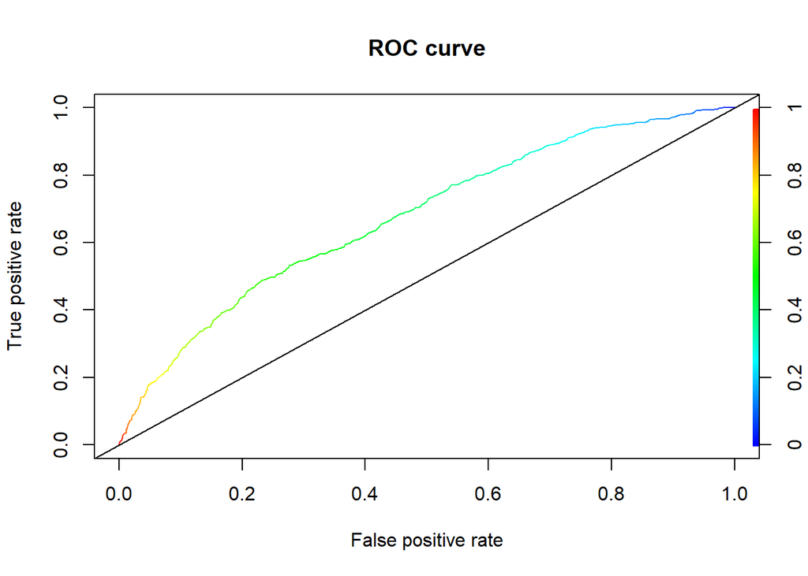

```
## AUC:  0.6764593
```

```r
evaluate_roc_auc(data, model)
```